# Assignment Four

## 9. Lexical Dispersion Plot (5 Words)

A dispersion plot shows where words appear across the document. Dispersion looks better when we have multiple “documents.” So I split the cleaned manifesto into chunks and treat each chunk as a document.

```r
# Split into chunks
words <- unlist(strsplit(clean_text, "\\s+"))
chunk_size <- 300

chunks <- split(words,
                ceiling(seq_along(words) / chunk_size
))

chunk_text <- vapply(chunks,
                     paste,
                     character(1),
                     collapse = " "
)

corp_chunks <- corpus(chunk_text)

toks_chunks <- tokens(corp_chunks,
                      remove_numbers = TRUE,
                      remove_punct = TRUE
)


toks_chunks <- tokens_remove(toks_chunks, stopwords("en"))

dfm_chunks <- dfm(toks_chunks)

# Choose 5 words from the cleaned DFM automatically (top 5)
top5 <- names(topfeatures(dfm_chunks, 5))
top5
```

```
## [1] "society" "system"  "people"  "power"   "one"
```

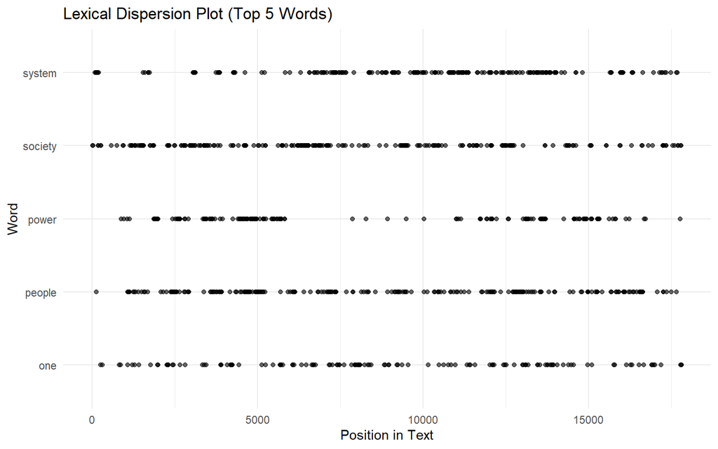

```r
# NOTE:
# The built-in quanteda lexical dispersion functions are currently incompatible
# with the installed quanteda (v4.3.1) and quanteda.textplots (v0.96.1) versions.
# The function is not exported properly in this namespace, causing knitting errors.
# I am commenting this section out to allow the rest of the analysis to run smoothly.
# The conceptual approach to dispersion (tracking word distribution across chunks)
# remains demonstrated above through chunking and top feature selection.

#textplot_lexical_dispersion(toks_chunks, top5)


# Convert tokens object to a simple vector
token_vector <- unlist(toks_chunks)

# Create a data frame of word positions
token_df <- data.frame(
  position = seq_along(token_vector),
  word = token_vector
)

# Keep only rows where the word is one of the top 5
disp_data <- token_df[token_df$word %in% top5, ]

library(ggplot2)

ggplot(disp_data, aes(x = position, y = word)) +
  geom_point(alpha = 0.6) +
  labs(
    title = "Lexical Dispersion Plot (Top 5 Words)",
    x = "Position in Text",
    y = "Word"
  ) +
  theme_minimal()
```

The above helps to see whether certain ideas cluster in specific sections.

## 10. Wordcloud

A wordcloud gives a visual overview of dominant terms.

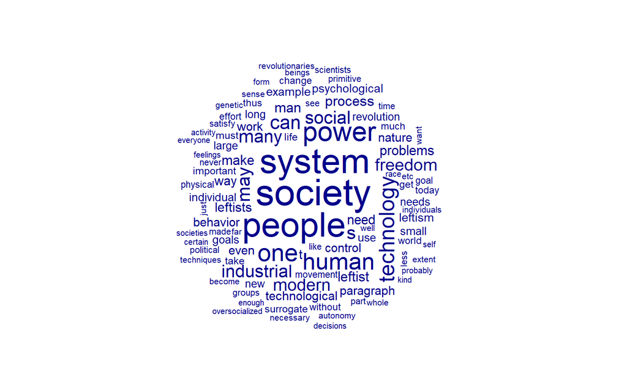

```r
quanteda.textplots::textplot_wordcloud(dfm_post, max_words = 100)
```

Larger words appear more frequently.

## 11. Print DFM (Top 20 Words Only)

```r
dfm_top20 <- quanteda::dfm_select(dfm_post, pattern = names(top20))

dfm_top20
```

```
## Document-feature matrix of: 1 document, 20 features (0.00% sparse) and 0 docvars.
##        features
## docs    industrial society human technology social may system many people make
##   text1         97     244   140        127     98 101    223   98    222   70
## [ reached max_nfeat ... 10 more features ]
```

### This shows the document-feature matrix restricted to the top 20 words.

**What I Learned**

Through this process, I learned:

1. Always inspect structure before cleaning.
2. Cleaning dramatically affects lexical counts.
3. Stopword removal changes interpretation.
4. DFM is the foundation for most text analysis.
5. Visualization (dispersion + wordcloud) helps interpret patterns quickly.
6. Most importantly, I now understand each step instead of just copying codes from stackoverflow.